# Отчёт по лабораторной работе №12

Программирование в командном процессоре ОС UNIX. Командные файлы

Автор

принадлежность

Терентеевская Светлана Александровна, Student

Российский университет дружбы народов

Дата публикации

2026-04-09

# Информация

## Докладчик

- Терентеевская Светлана Александровна
- Группа НКАбд-05-25, студент бакалавра
- Российский университет дружбы народов им. П. Лумумбы
- 1032253498@rudn.ru
- https://github.com/SvetlanaTerenteevskaya

# Вводная часть

## Цель работы

Изучить основы программирования в оболочке ОС UNIX/Linux. Научиться писать небольшие командные файлы.

## Задание

- Сделать резервную копию самого скрипта в каталог ~/backup с использованием архиватора.
- Обработать произвольное число аргументов командной строки.
- Вывести содержимое каталога и права доступа к файлам без использования ls и dir.

## Теоретическое введение

### Стандартные переменные

| Переменная | Назначение |
| --- | --- |
| `PATH` | Список каталогов для поиска команд (разделитель — двоеточие). По умолчанию: текущий каталог, `/bin`, `/usr/bin` |
| `HOME` | Домашний каталог пользователя |
| `IFS` | Разделители полей в командной строке (пробел, табуляция, перевод строки) |
| `MAIL` | Файл для проверки почты |
| `TERM` | Тип используемого терминала |
| `LOGNAME` | Регистрационное имя пользователя |

Просмотреть значения всех переменных можно командой `set`.

**Назначение основных метасимволов:**

- `*` — любая строка (в том числе пустая)
- `?` — один любой символ
- `[c1-c2]` — любой символ из диапазона

**Экранирование** — снятие специального смысла:

- Обратный слеш перед метасимволом
- Одинарные кавычки (полное экранирование)
- Двойные кавычки (частичное экранирование)

### Командные файлы

**Командный файл (скрипт)** — текстовый файл с последовательностью команд. Для запуска необходимо установить право на выполнение и указать путь к файлу.

### Функции

Функция определяется один раз в начале скрипта и может вызываться по имени.

### Специальные переменные для командных файлов

| Переменная | Назначение |
| --- | --- |
| `$0` | Имя скрипта |
| `$1`…`$9` | Аргументы командной строки |
| `$#` | Количество аргументов |
| `$@` | Все аргументы как отдельные слова |
| `$*` | Все аргументы как одна строка |
| `$?` | Код завершения последней выполненной команды |
| `$$` | PID текущего процесса |
| `$!` | PID последнего фонового процесса |
| `${#name}` | Длина строки в переменной `name` |
| `${name:-value}` | Если переменная не определена, подставляется значение |
| `${name:=value}` | ей присваивается значение |

### Команда getopts

`getopts` осуществляет синтаксический анализ командной строки, выделяя флаги (опции). Строка опций содержит список допустимых флагов; если после флага ожидается аргумент, ставится двоеточие. `getopts` использует переменные `OPTARG` (аргумент флага) и `OPTIND` (индекс следующего аргумента). Обычно `getopts` применяется в цикле `while` совместно с оператором `case`.

### Управляющие конструкции

#### Цикл for

Перебирает элементы списка, последовательно присваивая их переменной и выполняя заданные команды.

#### Оператор выбора case

Сравнивает значение переменной с несколькими шаблонами и выполняет команды, соответствующие первому совпавшему шаблону. Метасимвол `*` используется как шаблон по умолчанию.

#### Условный оператор if

Выполняет проверку условия. Если последняя команда в списке после `if` возвращает нулевой код (истина), выполняется блок `then`. Если нет — проверяется `elif` или выполняется блок `else`. Завершается конструкция служебным словом `fi`.

**Команда `test`** используется для проверки условий:

- `-d` — проверка, является ли файл каталогом
- `-f` — проверка, является ли файл обычным файлом
- `-r` — проверка доступа на чтение
- `-w` — проверка доступа на запись
- `-x` — проверка доступа на выполнение

#### Цикл while

Выполняется, пока последняя команда в списке условий возвращает нулевой код (истина).

#### Цикл until

Выполняется, пока последняя команда в списке условий возвращает ненулевой код (ложь). Условие выхода из цикла —противоположное `while`.

#### Команды true и false

- `true` — всегда возвращает нулевой код (истина)
- `false` — всегда возвращает ненулевой код (ложь)

#### Прерывание циклов

- `break` — полностью завершает выполнение цикла
- `continue` — завершает текущую итерацию и переходит к следующей

# Выполнение лабораторной работы

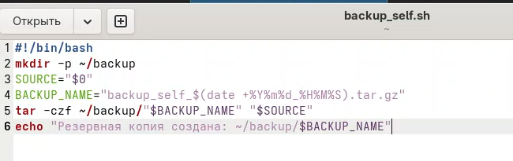

Рисунок 2: Скрипт для backup_self.sh

Запустила (рис. 3).

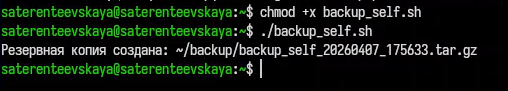

Рисунок 3: Запуск backup_self.sh

Проверила, что создался архив (2 раза) (рис. 4).

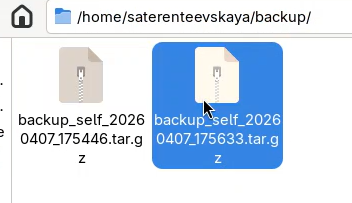

Рисунок 4: Проверка архива

2. Я написала пример командного файла, обрабатывающего любое произвольное число аргументов командной строки, в том числе превышающее десять (рис. 5).

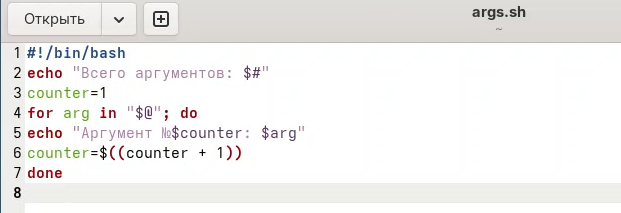

Рисунок 5: Скрипт для args.sh

Запустила с разными аргументами (рис. 6).

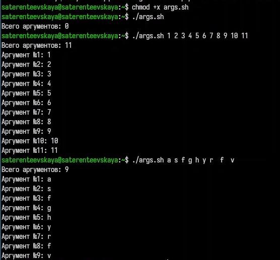

Рисунок 6: Запуск args.sh

3. Я написала командный файл — аналог команды ls (без использования самой этой команды и команды dir). Он выдает информацию о нужном каталоге и выводит информацию о возможностях доступа к файлам этого каталога (рис. 7, рис. 8)

[figure not shown]

Рисунок 7: Скрипт для myls.sh

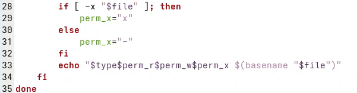

Рисунок 8: Скрипт для myls.sh

Запустила (рис. 9).

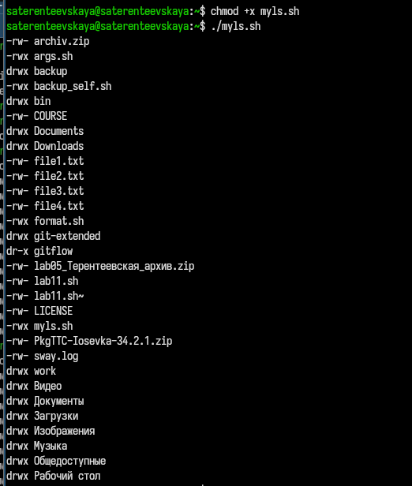

Рисунок 9: Запуск myls.sh

4. Я написала командный файл, который получает в качестве аргумента командной строки формат файла (.txt, .doc, .jpg, .pdf и т.д.) и вычисляет количество таких файлов в указанной директории. Путь к директории также передаётся в виде аргумента командной строки (рис. 10).

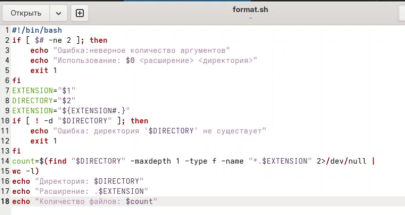

Рисунок 10: Скрипт для format.sh

Запустила и проверила с txt (рис. 11).

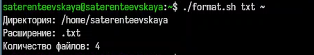

Рисунок 11: Количество txt-файлов

и sh (рис. 12).

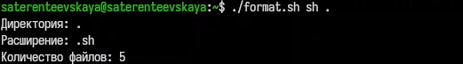

Рисунок 12: Количество sh-файлов

# Выводы

В ходе данной лабораторной работы я изучила основы программирования в оболочке ОС UNIX/Linux и научилась писать небольшие командные файлы.

# Список литературы

[ТУИС](https://esystem.rudn.ru)

[Методичка к лабораторной работе №12](https://esystem.rudn.ru/pluginfile.php/3097028/mod_resource/content/4/010lab_shell_prog_1.pdf)